# How can Teachers Effectively Predict Students’ Performance in Math?

#### Question 6 (extra credit)

##### 6.1

```r
min_shrinkage = 0
min_trees = 0
min_interaction = 0
min_mse = 10000
set.seed(2020)

for (i in seq(0.001, 0.01, 0.001)) {
  for (j in seq(1000, 5000, 1000)) {
    for (k in seq(1, 5)) {
      model = gbm(G3 ~ .,
                  data = train,
                  distribution = "gaussian",
                  shrinkage = i,
                  n.trees = j,
                  interaction.depth = k)
      predictions = predict(model, newdata = test, n.trees = j)
      mse = mean((predictions - test$G3)^2)
      if (mse < min_mse) {
        min_shrinkage = i
        min_trees = j
        min_interaction = k
        min_mse = mse
      }
    }
  }
}
```

```r
c(min_shrinkage, min_trees, min_interaction)
```

```
## [1] 6e-03 2e+03 1e+00
```

```r
model = gbm(G3 ~ .,
            data = train,
            distribution = "gaussian",
            shrinkage = min_shrinkage,
            n.trees = min_trees,
            interaction.depth = min_interaction)
```

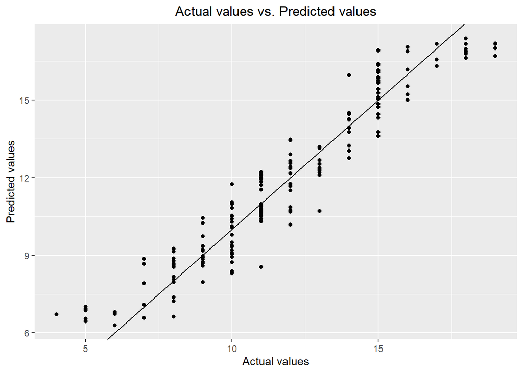

```r
predictions = predict(model, newdata = test, n.trees = 2000)
ggplot() +
  geom_point(aes(x = test$G3, y = predictions)) +
  geom_abline() +
  labs(x = "Actual values", y = "Predicted values", title = "Actual values vs. Predicted values") +
  theme(plot.title = element_text(hjust = 0.5))
```

The model did a better job in predicting the value, but still performs worse than Ridge / Lasso regression.

##### Question 6.2

```r
round(mean((predictions - test$G3)^2), 3)
```

```
## [1] 0.95
```

The MSE for the optimized model is lower than the MSE in question 4, but is still higher than Ridge / Lasso regression.

##### Question 6.3

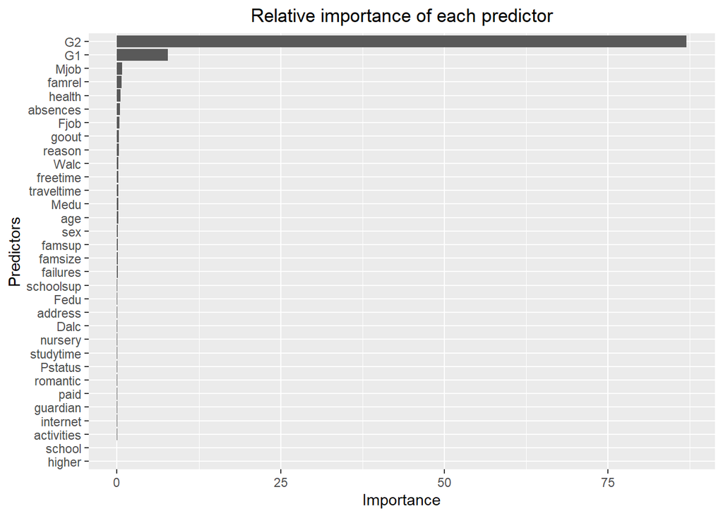

```r
importance = summary.gbm(model, plotit = FALSE)
df = data.frame(
  name = importance$var,
  value = importance$rel.inf
)

ggplot(df, aes(x = reorder(name, value), y = value)) +
  geom_bar(stat = "identity") +
  labs(x = "Predictors", y = "Importance", title = "Relative importance of each predictor") +
  theme(plot.title = element_text(hjust = 0.5)) +
  coord_flip()
```

As shown above, `G2` still has a dominate importance in the model.

### Conclusion

The two previous reports show that it is nearly impossible to achieve a high accuracy rate without including the first and second midterm grades. By adding these two variables, the accuracy increased significantly, and the MSE also reduced. This however adds more limitation to prediction, as teachers will need to obtain some grade in the course to predict the final grade, as opposed to predict purely based on factors that can be obtained before the semester.